# MacroEcol_5_Polarization

Laura Ospina-Rozo

25/04/2022

Specifically, we first linearise the RBGs using the parameters derived from the MATLAB code adapted from Stevens et al 2007 (Biological Journal of the Linnean society, 90(2), 211-237).

Next we equalise the RGB values with the grey standard with known reflectance.

Then we calculate the difference between the two polarizations standardized by their sum.

Finally we correlate the polarization with reflectivity obtained in previous scripts

# Setting up

## General

Libraries sourced from an additional script

```r
source("./MacroEcol_1_Libraries.R")
```

We included an overall option to keep as many decimals as possible in our data, which is important for our calculations

```r
options(scipen = 100)
```

We imported the data set containing ecological and phylogeny data obtained in previous steps.

```r
Cons1 <- read.csv("../Data/FromCode/ConsReflEcolInd.csv")[-1]
```

## Parameters

To calibrate, we photographed a set of 2%, 20%, 40%, 60%, 80% and 99% and standards. Then, we fitted a polynomial regression between the RGB values the standards display in our set up and their expected reflectance on each channel (obtained from the manufacturer), using a custom made function in MatLab.

Since the pictures were not taken on the same day, we calibrated the beetle photographs to the photographs of the standards taken on the same day. That means we had one set of parameters for each camera configuration (in the code this is called camera_cat)

The parameters obtained from these curves were stored in .txt files, so we wrote a function to import them directly.

```r
read_parameters_from_file <- function(camera_cat, type) {
  param <- read.table(paste0("../Data/ParametersMatLab/StandardParams",
                             camera_cat, type, ".txt"), header=TRUE) %>%
  select(1:5,7) %>%
  mutate(camera_cat = rep(camera_cat)) %>%
  mutate(type=rep(type))

  return(param)
}

parameter0 <-
  bind_rows(
  read_parameters_from_file("J21", "LCP"),
  read_parameters_from_file("J21", "RCP"),
  read_parameters_from_file("J21", "VIS"),

  read_parameters_from_file("J25", "LCP"),
  read_parameters_from_file("J25", "RCP"),
  read_parameters_from_file("J25", "VIS"),

  read_parameters_from_file("J26", "LCP"),
  read_parameters_from_file("J26", "RCP"),
  read_parameters_from_file("J26", "VIS"),

  read_parameters_from_file("F01", "LCP"),
  read_parameters_from_file("F01", "RCP"),
  read_parameters_from_file("F01", "VIS"),

  read_parameters_from_file("F04", "LCP"),
  read_parameters_from_file("F04", "RCP"),
  read_parameters_from_file("F04", "VIS")

  )
```

The regression uses 4 parameters a, b, c, and d. We obtained one value for each parameter, on each channel (R,G, B) for each type of filter (VIS = Visible, LCP =left handed circularly polarized and RCP= right circularly polarized) on each camera configuration (camera_cat)

```r
parameter <-
  parameter0 %>% filter(Channel != "Gy") %>% # keep only the channels R, G, B.
  select(-5) %>% # this column is the % of fitting (ideally) above 0.99)
  gather(key = parameter,
         value = value,
         - Channel, -type, -camera_cat) #re-arrange: All parameters in 1 column

head(parameter)
```

```
##   Channel camera_cat type parameter             value
## 1       R        J21  LCP         a 2384.835490000000
## 2       G        J21  LCP         a    0.000543537042
## 3       B        J21  LCP         a    0.027512358400
## 4       R        J21  RCP         a    0.010489709500
## 5       G        J21  RCP         a    0.000006682114
## 6       B        J21  RCP         a    0.000202935085
```

## Grey Standard

This is the known reflectance (from manufacturer) of the 40% grey placed next to each beetle in the photographs

```r
grey_standard_refl <- read.csv("../Data/12_knownGreyStdReflectance.csv")
```

## Raw RGB values

These are the RGB valuyes extracted from the calibrated photographs. We considered one region of interest (ROI) in one elytron and one in the pronotum. We also sampled the 40% grey as a reference.

**Elytra**

We separated the RGB values of the elytra and the grey standard but kept a unique identifier called PhotoID. This helps pairing the sample with the grey that was in that picture further in the analysis (required to run the linearisation function).

```r
RGBElytraNGrey <-
  RGB_raw_transform %>%
  filter(tr != "Pronotum") %>% # remove data for the pronotum
  unite("PhotoID", # Create a unique code
        c(1,2,4), # which contains the individual_Filter_Channel
        remove=FALSE) # still keep all the original columns

# Each beetle sample has a grey standard in the same photo.
levels(as.factor(RGBElytraNGrey$tr))
```

```
## [1] "Elytra" "Grey"
```

```r
# We will separate the elytra and grey
# but they will still share the unique PhotoID to pair them later

RGBElytra <-
  RGBElytraNGrey %>%
  filter(tr == "Elytra")

RGBElGrey <-
  RGBElytraNGrey %>%
  filter(tr == "Grey")
```

**Pronotum**

Pronotum data was not available for the following beetles:

```r
RGBPronot1 <-
  RGB_raw_transform %>%
  filter(tr != "Elytra") %>%  # remove data for the elytra
  unite("PhotoID", # Create a unique code
        c(1,2,4), # which contains the individual_Filter_Channel
        remove=FALSE) # still keep all the original columns

inPGind <- levels(as.factor(RGBPronot1[RGBPronot1$tr=="Grey",]$ind))
inPRind <- levels(as.factor(RGBPronot1[RGBPronot1$tr=="Pronotum",]$ind))

setdiff(inPGind,inPRind)
```

```
## [1] "ecry03" "mcla02" "roci02"
```

```r
setdiff(inPRind,inPGind)
```

```
## character(0)
```

```r
# Note pronotum missing for these: "ecry03" "mcla02" "roci02"
```

They are considered for the overall polarization analysis but not in the correlations elytra-pronotum.

We separated the RGB values of the pronotum and the grey standard but kept a unique identifier called PhotoID. This helps pairing the sample with the grey that was in that picture further in the analysis (required to run the linearisation function).

```r
RGBPronot1 <-
  RGBPronot1 %>%
  filter(ind != "ecry03" &
         ind != "mcla02" &
         ind != "roci02") # Remove these species because pronotum unavailable

RGBPronot <-
  RGBPronot1 %>%
  filter(tr == "Pronotum")

RGBPrGrey <-
  RGBPronot1 %>%
  filter(tr == "Grey")
```

# Calibrations

Here we linearise and equalise RGBs for each camera setting and each channel separately.

First we defined the functions as follows:

**Linearization**

$$\ Y = a*exp(b*x) + c*exp(d*x)$$
Where a, b c and d are the parameters obtained from MatLab. x is the raw RGB value for the ROI and Y is the linearised value

```r
#The arguments of this functions are:
# a DataFrame: containing the RGB values that we want to linearise
# a ParameterData: a data frame containing the parameters a,b,c,d from MatLab

lin_equ_RGB <- function(DataFrame,ParameterData){
  Result <- DataFrame # keep the original data, results will be added to it
  Result$Linearized <- rep("NA",length(DataFrame[1])) # add an empty column

  for (i in 1:length(DataFrame$PhotoID)) {

    para <- ParameterData %>% # the data frame with the parameters

      # For each line in the DataFrame to linearise, we need to find
      # the correspondent set of parameters:
      filter(type == DataFrame$type[i] &  # VIS, LCP, or RCP
             Channel == DataFrame$Channel[i] & # R, G or B
             camera_cat == DataFrame$camera_cat[i]) %>% # Camera conditions
             arrange(.,parameter) # arranged alphabetically

    # Apply the formula
     Result$Linearized[i]<-
       para$value[1] * exp(para$value[2] * Result$value[i]) +
       para$value[3] * exp(para$value[4] * Result$value[i])

  }
  return(Result)
}
```

**Equalisation**

$$\ E = l / (rg /(kg*255))$$
Where rg is the raw RGB values for the grey in the photo, kg is the known reflectance of the gray standard (from the fabricator), l is the linearised value of the ROI and E is the equalised value of the ROI.

For this part we did not use and equation, rather we obtained the calculations directly form the data frames.

## Elytra

#### Linearise

We applied the function defined in the previous step

```r
LinearizedElytra <- lin_equ_RGB(RGBElytra,parameter) %>%
  select(PhotoID, tr, Linearized) # apply function

head(LinearizedElytra)
```

```
##        PhotoID     tr         Linearized
## 1 abno01_VIS_B Elytra 0.0433459224340714
## 2 abno01_LCP_B Elytra   0.06478427380179
## 3 abno01_RCP_B Elytra 0.0491076172571187
## 4 abno01_VIS_G Elytra 0.0739528114682013
## 5 abno01_LCP_G Elytra 0.0978269786698409
## 6 abno01_RCP_G Elytra 0.0954403321081553
```

```r
LinearizedElytra$Linearized <- round(as.numeric
                                     (LinearizedElytra$Linearized),4 ) # round

LinearizedElytraSpr <-
  LinearizedElytra %>%
  spread(tr,Linearized)
```

#### Equalise

And then equalised following the equation

```r
RGBElGreys <-
  RGBElGrey %>%
  select(PhotoID,value) # select the relevant columns of the raw grey values

EQElytra <-
  merge(RGBElGreys,LinearizedElytraSpr,
        all=FALSE) %>%
  rename(RawGrey = value) %>%
  mutate(Equalized =
           Elytra/(RawGrey/(grey_standard_refl[1,2]*255)))
```

#### Average

We averaged the RGB values of the three channels for each filter.

```r
RGB_ave <- EQElytra %>%
  select(PhotoID,Equalized) %>%
  mutate(Reflectance = Equalized * 100) %>%
  select(-Equalized) %>%
  separate(PhotoID,c("ind","Type","Channel"), sep="_") %>%
  group_by(ind, Type) %>%
  mutate(RGB_ave = mean(Reflectance)) %>%
  select(ind, Type ,RGB_ave) %>%
  distinct() %>%  # leave only the one row for each individual
  filter(!grepl('ambl', ind)) %>%
  filter(!grepl('sqzb', ind)) # remove, absent in the phylogeny

head(RGB_ave)
```

```
## # A tibble: 6 x 3
## # Groups:   ind, Type [6]
##   ind    Type  RGB_ave
##   <chr>  <chr>   <dbl>
## 1 abno01 LCP      7.40
## 2 abno01 RCP      6.61
## 3 abno01 VIS      5.31
## 4 abno02 LCP      5.95
## 5 abno02 RCP      5.15
## 6 abno02 VIS      4.15
```

## Pronotum

#### Linearise

We applied the function defined in the previous step

```r
LinearizedPron <- lin_equ_RGB(RGBPronot,parameter) %>%
  select(PhotoID, tr, Linearized) # apply function

head(LinearizedPron)
```

```
##        PhotoID       tr         Linearized
## 1 rept01_VIS_R Pronotum 0.0486138501955103
## 2 rept01_VIS_G Pronotum 0.0493577182264623
## 3 rept01_VIS_B Pronotum  0.039301457688771
## 4 rept01_LCP_R Pronotum 0.0519620880912811
## 5 rept01_LCP_G Pronotum 0.0636280773901934
## 6 rept01_LCP_B Pronotum 0.0439852217645462
```

```r
LinearizedPron$Linearized <- round(as.numeric
                                   (LinearizedPron$Linearized),4 ) # round

LinearizedPronSpr <-
  LinearizedPron %>%
  spread(tr,Linearized)
```

#### Equalise

And then equalised following the equation

```r
RGBPrGreys <-
  RGBPrGrey %>%
  select(PhotoID,value) # select the relevant columns of the raw grey values

EQPronot <-
  merge(RGBPrGreys,LinearizedPronSpr,
        all=FALSE) %>%
  rename(RawGrey = value) %>%
  mutate(Equalized =
           Pronotum/(RawGrey/(grey_standard_refl[1,2]*255)))
```

#### Average

We averaged the RGB values of the three channels for each filter.

```r
RGB_avePr <- EQPronot %>%
  select(PhotoID,Equalized) %>%
  mutate(Reflectance = Equalized * 100) %>%
  select(-Equalized) %>%
  separate(PhotoID,c("ind","Type","Channel"), sep="_") %>%
  group_by(ind, Type) %>%
  mutate(RGB_aveP = mean(Reflectance)) %>%
  select(ind, Type ,RGB_aveP) %>%
  distinct() %>%  # leave only the one row for each individual
  filter(!grepl('ambl', ind)) %>%
  filter(!grepl('sqzb', ind)) # remove, absent in the phylogeny

head(RGB_avePr)
```

```
## # A tibble: 6 x 3
## # Groups:   ind, Type [6]
##   ind    Type  RGB_aveP
##   <chr>  <chr>    <dbl>
## 1 abno01 LCP       6.60
## 2 abno01 RCP       5.68
## 3 abno01 VIS       4.68
## 4 abno02 LCP       5.76
## 5 abno02 RCP       4.81
## 6 abno02 VIS       4.01
```

# Polarization

We calculated the polarization as
$$\ P \
= \frac{l - r}{l + r}$$

where $l$ represents the mean reflectance under the filter for left handed circular polarization and $r$ represents the mean reflectance under the filter for right handed circular polarization.

## Elytra

Thus we obtained the polarization values for the elytron ROI by individual:

```r
# Calculate the polarization:
ElyPol <-
  RGB_ave %>%
  spread(Type,RGB_ave) %>%
  mutate(Polarization =  (LCP - RCP) / (LCP + RCP))

head(ElyPol) # by individual
```

```
## # A tibble: 6 x 5
## # Groups:   ind [6]
##   ind      LCP   RCP   VIS Polarization
##   <chr>  <dbl> <dbl> <dbl>        <dbl>
## 1 abno01  7.40  6.61  5.31       0.0563
## 2 abno02  5.95  5.15  4.15       0.0723
## 3 anom01  4.18  3.17  2.52       0.136
## 4 anom02  3.81  2.62  2.43       0.185
## 5 atki01  7.53  4.00  5.17       0.306
## 6 atki02  7.04  3.76  4.85       0.304
```

And by species:

```r
# Average: One polarization value by spp
ElyPolbysp <-
  ElyPol %>%
  select(ind, Polarization) %>%
  mutate(spp= substr(ind,1,4)) # Add column for spp

EPolbs <-
  ElyPolbysp[2:3] %>%
  group_by(spp) %>%
  summarise(Pol = mean(Polarization)) # by species

head(EPolbs)
```

```
## # A tibble: 6 x 2
##   spp      Pol
##   <chr>  <dbl>
## 1 abno  0.0643
## 2 anom  0.161
## 3 atki  0.305
## 4 aurs  0.206
## 5 boid  0.0885
## 6 brev  0.0871
```

## Pronotum

Thus we obtained the polarization values for the pronotum ROI by individual:

```r
# Calculate the polarization:
ProPol <-
  RGB_avePr %>%
  spread(Type,RGB_aveP) %>%
  mutate(Polarization =  (LCP - RCP) / (LCP + RCP))

head(ProPol) #  by individual
```

```
## # A tibble: 6 x 5
## # Groups:   ind [6]
##   ind      LCP   RCP   VIS Polarization
##   <chr>  <dbl> <dbl> <dbl>        <dbl>
## 1 abno01  6.60  5.68  4.68       0.0749
## 2 abno02  5.76  4.81  4.01       0.0891
## 3 anom01  4.15  3.01  2.60       0.160
## 4 anom02  4.30  3.12  2.88       0.159
## 5 atki01  3.28  2.65  2.41       0.107
## 6 atki02  3.60  2.75  2.56       0.135
```

And by species:

```r
# Average: One polarization value by spp
ProPolbysp <-
  ProPol %>%
  select(ind, Polarization) %>%
  mutate(spp= substr(ind,1,4)) # Add column for spp

PPolbs <-
  ProPolbysp[2:3] %>%
  group_by(spp) %>%
  summarise(Pol = mean(Polarization)) # by species

head(PPolbs)
```

```
## # A tibble: 6 x 2
##   spp      Pol
##   <chr>  <dbl>
## 1 abno  0.0820
## 2 anom  0.160
## 3 atki  0.121
## 4 aurs  0.410
## 5 boid  0.116
## 6 brev  0.0606
```

## Consolidates

### Body Part

First make sure the two data frames contain the same number of species, thus the differences between the individuals in both data frames should be 0

```r
ProPol <-
  ProPol %>%
  rename(PronotPol = Polarization)

ElyPol <-
  ElyPol %>%
  rename(ElytrPol = Polarization) #Keep all spp for other tests


ElyPolEP <-
  ElyPol %>%
  filter(ind != "ecry03" &
         ind != "mcla02" &
         ind != "roci02") # Removed, pronotum unavailable

inelytra <- levels(as.factor(ElyPolEP$ind))
inpronotum <- levels (as.factor(ProPol$ind))

setdiff(inelytra,inpronotum)
```

```
## character(0)
```

```r
setdiff(inpronotum,inelytra)
```

```
## character(0)
```

Merge

```r
# simplify Data frames
Elysimple <-
  ElyPolEP %>%
  select(ind, ElytrPol )

Prosimple <-
  ProPol %>%
  select(ind, PronotPol)

BeetlePol <-
  merge (Elysimple,Prosimple) %>%   # Combine the two data frames
  mutate(Difference = ElytrPol-PronotPol)

head(BeetlePol)
```

```
##      ind   ElytrPol  PronotPol  Difference
## 1 abno01 0.05631758 0.07485419 -0.01853661
## 2 abno02 0.07228979 0.08905251 -0.01676271
## 3 anom01 0.13646753 0.15996365 -0.02349612
## 4 anom02 0.18547191 0.15926191  0.02621000
## 5 atki01 0.30583122 0.10721581  0.19861541
## 6 atki02 0.30355419 0.13451403  0.16904016
```

### Ecological variables

We merged the polarization data with the data frames obtained in previous steps that contain ecological variables, reflectivity, size and the species name as follows:

First compare the dimensions of the two data frames (Reflectance and polarization):

```r
Cons1 <-
  Cons1 %>%
  mutate(spp = substr(ind,1,4))

inTree <- levels(as.factor(Cons1$spp))
inRGB <- levels (as.factor(EPolbs$spp))

setdiff(inTree,inRGB)
```

```
## character(0)
```

```r
setdiff(inRGB,inTree)
```

```
## character(0)
```

Both contain the same species

```r
#Compare length:
length(Cons1$ind)
```

```
## [1] 261
```

```r
length(ElyPol$ind)
```

```
## [1] 177
```

```r
# subset the consolidated by the ind in polariz data frame
Refbyind <- Cons1[Cons1$ind %in% ElyPol$ind, ]
```

But since they had different numbers of individuals we only considered the ones that were common for both data frames to combine them into one larger data frame

```r
# Simplify the polarization data
ElyPolbyind <-
  ElyPol %>%
  select(1,5) # keep only one column and the individual

RPData <-
  merge (Refbyind,ElyPolbyind) # Combine the two

head(RPData)
```

```
##      ind    R_ALL     R_VIS    R_NIR        Res   size         phylogeny_name
## 1 abno01 24.36959 15.194950 32.37499 -9.8258343 1.5390 Anoplognathus_abnormis
## 2 abno02 30.17203 17.865117 40.90967 -3.9177421 1.6120 Anoplognathus_abnormis
## 3 anom01 17.25955  2.229028 30.33292  0.8864166 1.7630        Anomala_antigua
## 4 anom02 19.93132  7.888188 30.40910 -4.6042095 1.7675        Anomala_antigua
## 5 atki01 15.52166  6.194366 23.61734 -9.7297912 2.4590   Calloodes_atkinsonii
## 6 atki02 18.73437  6.636925 29.23785 -4.5446134 2.0180   Calloodes_atkinsonii
##          PC1         PC2  spp   ElytrPol
## 1 -2.1441633  0.07156382 abno 0.05631758
## 2 -1.8227362  0.16083346 abno 0.07228979
## 3 -2.3016135 -2.27652672 anom 0.13646753
## 4 -0.3855034 -1.15167811 anom 0.18547191
## 5 -2.7414058  1.08031739 atki 0.30583122
## 6 -2.7414058  1.08031739 atki 0.30355419
```

We also summarised this data by species

```r
RPDataAgg <-
  RPData %>%
  dplyr::select (-ind,-spp) %>%# remove individual id
  dplyr::select (phylogeny_name, everything ()) %>% # order columns
  group_by (phylogeny_name) %>%  # group
  summarise (across(everything(), list(mean))) # mean

head(RPDataAgg)
```

```
## # A tibble: 6 x 9
##   phylogeny_name  R_ALL_1 R_VIS_1 R_NIR_1   Res_1 size_1 PC1_1  PC2_1 ElytrPol_1
##   <chr>             <dbl>   <dbl>   <dbl>   <dbl>  <dbl> <dbl>  <dbl>      <dbl>
## 1 Anomala_antigua    18.6    5.06    30.4  -1.86    1.77 -1.34 -1.71      0.161
## 2 Anoplognathus_~    27.3   16.5     36.6  -6.87    1.58 -1.98  0.116     0.0643
## 3 Anoplognathus_~    22.1   10.4     32.3  -5.22    3.11 -1.90  0.419     0.112
## 4 Anoplognathus_~    42.6   34.7     49.5 -11.9     1.71 -3.49 -0.434     0.206
## 5 Anoplognathus_~    31.1   17.3     43.2  -1.06    2.61 -1.64 -0.922     0.0885
## 6 Anoplognathus_~    27.4   12.9     40.1   0.236   2.51 -1.15 -3.63      0.0871
```

This way we can conduct the analysis at both individual and species level

# Questions

## Body part

**Question**

It is possible that different selective pressures apply to the elytra than to other parts of the beetle body. There are various species that seem to have stronger structural coloration in the pronotum. They may have lost the polarization in their elytra.

**Are there differences in the polarization between the elytra and pronotum of the same individual?**

**Setting up**

**Model**

A paired t-test to compare the mean of the difference to 0.A negative difference would mean that in general the pronotum is more polarized than the elytra.

```r
# Paired t test
t.test(BeetlePol$Difference)
```

```
##
##  One Sample t-test
##
## data:  BeetlePol$Difference
## t = -1.2468, df = 173, p-value = 0.2142
## alternative hypothesis: true mean is not equal to 0
## 95 percent confidence interval:
##  -0.019894362  0.004490845
## sample estimates:
##    mean of x
## -0.007701759
```

The mean difference in polarization between the two body parts is not significantly different than 0.

**Plots**

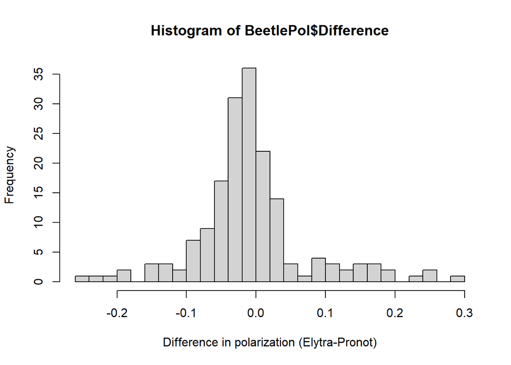

```r
hist(BeetlePol$Difference, breaks =20, xlab="Difference in polarization (Elytra-Pronot)", ylab="Frequency")
```

These beetles with higher polarization in their elytra are:

```r
ElytraMoreP <-
  BeetlePol %>%
  filter (Difference > 0.1)

ElytraMoreP$ind
```

```
##  [1] "atki01" "atki02" "brun01" "brun04" "brun05" "ecry01" "fchi01" "fchi02"
##  [9] "hirs03" "lats01" "lats03" "pvul02" "pvul03" "pvul04" "rayn01" "rayn03"
## [17] "smgr01"
```

These beetles with higher polarization in their pronotum are:

```r
PronotumMoreP <-
  BeetlePol %>%
  filter (Difference < -0.1)

PronotumMoreP$ind
```

```
##  [1] "aurs01" "aurs02" "clor09" "meli02" "meli03" "neus01" "oliv03" "opal01"
##  [9] "pvul01" "rubi01" "rubi02" "vrdi01" "vrdi03"
```

## VIS Reflectivity

**Question**

It has been hypothesized that the chiral structures associated to polarization sensitivity are more effective reflecting light than pigments or other structures. This may be true considering that they can produce broad band metallic colours. However, it is also possible that chiral structures produce highly saturated angle-dependent colours which would mean reflecting a very narrow section of the spectrum.

**Is more polarization correlated with more reflectivity in the visible spectrum?**

**Tests**

There is a positive correlation between the degree of polarization and the amount of visible light reflected (reflectivity)

Individual level:

```r
cor.test(RPData$R_VIS,RPData$ElytrPol) # by individual
```

```
##
##  Pearson's product-moment correlation
##
## data:  RPData$R_VIS and RPData$ElytrPol
## t = 3.0233, df = 172, p-value = 0.002884
## alternative hypothesis: true correlation is not equal to 0
## 95 percent confidence interval:
##  0.07848249 0.36132464
## sample estimates:
##       cor
## 0.2246296
```

```r
modPol1 <- lm(RPData$R_VIS~RPData$ElytrPol) #by individual
summary(modPol1)
```

```
##
## Call:
## lm(formula = RPData$R_VIS ~ RPData$ElytrPol)
##
## Residuals:
##     Min      1Q  Median      3Q     Max
## -13.268  -4.616  -1.074   4.329  19.567
##
## Coefficients:
##                 Estimate Std. Error t value             Pr(>|t|)
## (Intercept)      13.8982     0.5864  23.701 < 0.0000000000000002 ***
## RPData$ElytrPol  11.7168     3.8756   3.023              0.00288 **
## ---
## Signif. codes:  0 '***' 0.001 '**' 0.01 '*' 0.05 '.' 0.1 ' ' 1
##
## Residual standard error: 7.008 on 172 degrees of freedom
## Multiple R-squared:  0.05046,    Adjusted R-squared:  0.04494
## F-statistic:  9.14 on 1 and 172 DF,  p-value: 0.002884
```

Species level:

```r
cor.test(RPDataAgg$R_VIS_1,RPDataAgg$ElytrPol_1) # by spp
```

```
##
##  Pearson's product-moment correlation
##
## data:  RPDataAgg$R_VIS_1 and RPDataAgg$ElytrPol_1
## t = 1.2718, df = 45, p-value = 0.21
## alternative hypothesis: true correlation is not equal to 0
## 95 percent confidence interval:
##  -0.1065918  0.4494039
## sample estimates:
##       cor
## 0.1862769
```

```r
modPol3 <- lm(RPDataAgg$R_VIS_1~RPDataAgg$ElytrPol_1) # by spp
summary(modPol3)
```

```
##
## Call:
## lm(formula = RPDataAgg$R_VIS_1 ~ RPDataAgg$ElytrPol_1)
##
## Residuals:
##      Min       1Q   Median       3Q      Max
## -11.4306  -5.5192  -0.0809   4.5235  19.0338
##
## Coefficients:
##                      Estimate Std. Error t value           Pr(>|t|)
## (Intercept)            13.743      1.227  11.204 0.0000000000000131 ***
## RPDataAgg$ElytrPol_1    9.486      7.458   1.272               0.21
## ---
## Signif. codes:  0 '***' 0.001 '**' 0.01 '*' 0.05 '.' 0.1 ' ' 1
##
## Residual standard error: 7.123 on 45 degrees of freedom
## Multiple R-squared:  0.0347, Adjusted R-squared:  0.01325
## F-statistic: 1.618 on 1 and 45 DF,  p-value: 0.21
```

**Plots**

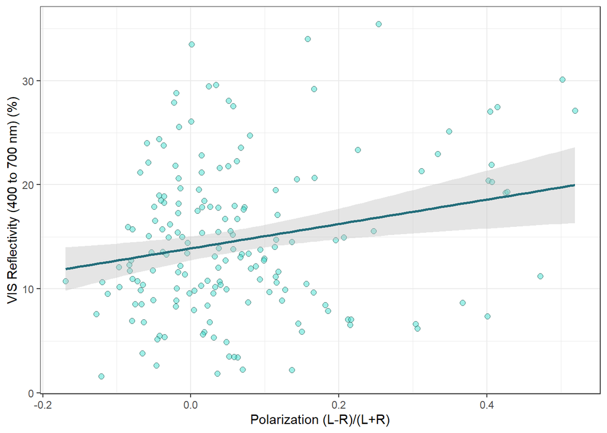

Relationship between polarization and VIS reflectivity by individual

```r
ggplot(RPData, aes(ElytrPol,R_VIS)) +
     geom_point(pch=21, bg="turquoise", col="black", alpha=0.5, size=2)+
     ylab("VIS Reflectivity (400 to 700 nm) (%)")+
     xlab("Polarization (L-R)/(L+R)")+
     theme_bw() +
  geom_smooth(method=lm, alpha=0.4, col="#226D7A", fill="grey")
```

```r
ToPlotPolbsp <-
  RPData %>%
  dplyr::select (-phylogeny_name) %>%
  mutate("spp" = substr(ind,1,4)) %>%
  select(-1) %>%
  group_by(spp) %>%
  summarise(meanAll = mean(R_ALL),
            meanVIS = mean(R_VIS),
            meanNIR = mean(R_NIR),
            meanRes = mean(Res),
            meanPol = mean(ElytrPol),
            meanSize = mean(size),
            sdAll = sd(R_ALL),
            sdVIS = sd(R_VIS),
            sdNIR = sd(R_NIR),
            sdRes = sd(Res),
            sdPol = sd(ElytrPol),
            sdSize = sd(size))
```

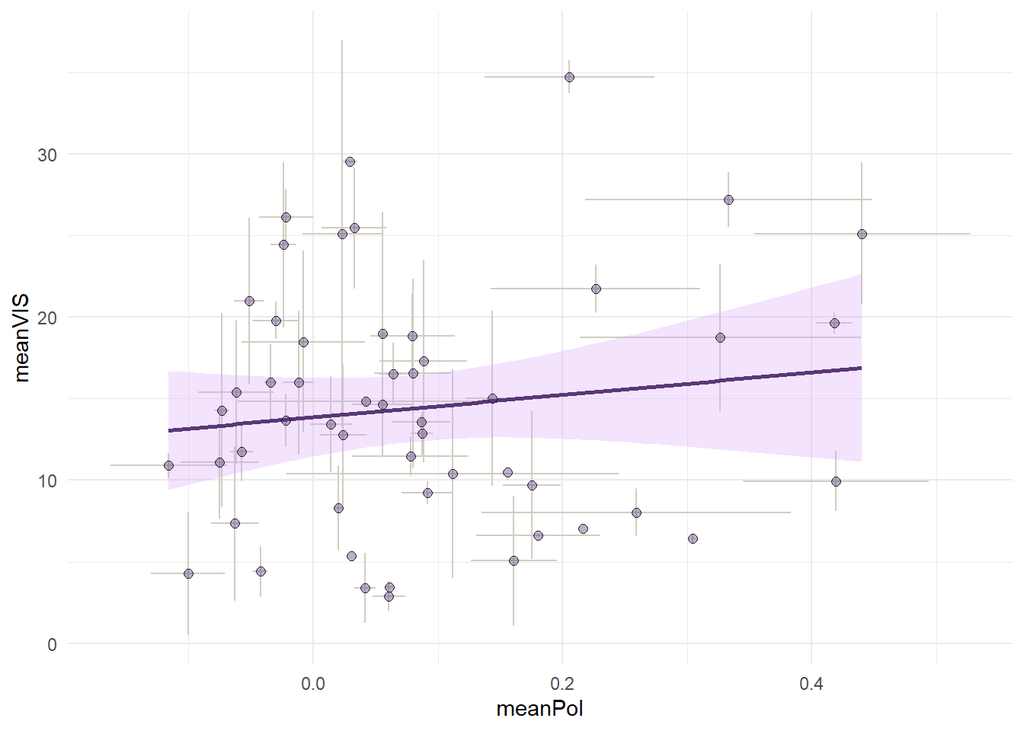

Relationship between polarization and VIS reflectivity by species

```r
ggplot(ToPlotPolbsp, aes(x = meanPol, y = meanVIS))+
    geom_errorbar(aes(ymin = meanVIS - sdVIS,
                    ymax = meanVIS + sdVIS),
                col="#cecec2") +
  geom_errorbarh(aes(xmin = meanPol - sdPol,
                     xmax = meanPol + sdPol),
                 col="#cecec2") +
  geom_smooth (method="lm", color="#593876", fill="#D7A1F9", alpha=0.3)+
  geom_point(size=2, alpha=0.4, colour= "#593876")+
  geom_point(size=2, pch=21, colour="black", alpha=0.7)+
  theme_minimal()+
  theme(legend.position = "none")
```

**Conclusion**

**Yes, Beetles with more polarization reflect more visible light**

## NIR Reflectivity

**Question**

The relationship between polarization and NIR is unknown. It has been observed that some beetles produce iridescence in NIR which could mean they have multilayers or a chiral structure to reflect long wavelengths. Considering that reflectance in visible and NIR are often correlated, it is reasonable to expect a similar pattern that the one observed for visible light.

**Is more polarization correlated with more reflectivity in the NIR?**

**Tests**

There is a negative correlation between the NIR reflectivity and polarization.

Individual level:

```r
cor.test(RPData$R_NIR,RPData$ElytrPol) # by individual
```

```
##
##  Pearson's product-moment correlation
##
## data:  RPData$R_NIR and RPData$ElytrPol
## t = -2.384, df = 172, p-value = 0.01821
## alternative hypothesis: true correlation is not equal to 0
## 95 percent confidence interval:
##  -0.31912578 -0.03089924
## sample estimates:
##        cor
## -0.1788469
```

```r
modPol2 <- lm(RPData$R_NIR~RPData$ElytrPol) # by individual
summary(modPol2)
```

```
##
## Call:
## lm(formula = RPData$R_NIR ~ RPData$ElytrPol)
##
## Residuals:
##     Min      1Q  Median      3Q     Max
## -24.088  -7.564  -1.795   5.471  38.229
##
## Coefficients:
##                 Estimate Std. Error t value            Pr(>|t|)
## (Intercept)       41.953      0.930  45.112 <0.0000000000000002 ***
## RPData$ElytrPol  -14.653      6.146  -2.384              0.0182 *
## ---
## Signif. codes:  0 '***' 0.001 '**' 0.01 '*' 0.05 '.' 0.1 ' ' 1
##
## Residual standard error: 11.11 on 172 degrees of freedom
## Multiple R-squared:  0.03199,    Adjusted R-squared:  0.02636
## F-statistic: 5.683 on 1 and 172 DF,  p-value: 0.01821
```

Species level:

```r
cor.test(RPDataAgg$R_NIR_1,RPDataAgg$ElytrPol_1) # by species
```

```
##
##  Pearson's product-moment correlation
##
## data:  RPDataAgg$R_NIR_1 and RPDataAgg$ElytrPol_1
## t = -1.7956, df = 45, p-value = 0.07928
## alternative hypothesis: true correlation is not equal to 0
## 95 percent confidence interval:
##  -0.50801220  0.03089468
## sample estimates:
##        cor
## -0.2585661
```

(Correlation is lost when considering the average per species)

**Plots**

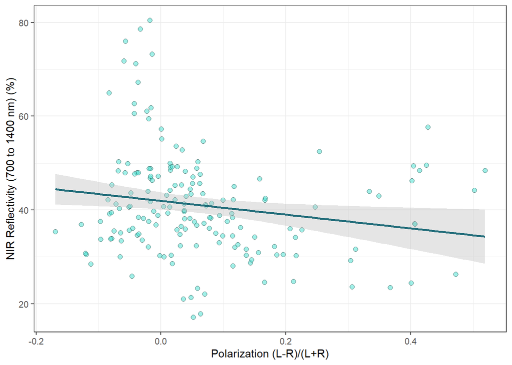

Relationship between polarization and NIR reflectivity by individual

```r
ggplot(RPData, aes(ElytrPol,R_NIR)) +
     geom_point(pch=21, bg="turquoise", col="black", alpha=0.5, size=2)+
     ylab("NIR Reflectivity (700 to 1400 nm) (%)")+
     xlab("Polarization (L-R)/(L+R)")+
     theme_bw() +
  geom_smooth(method=lm, alpha=0.4, col="#226D7A", fill="grey")
```

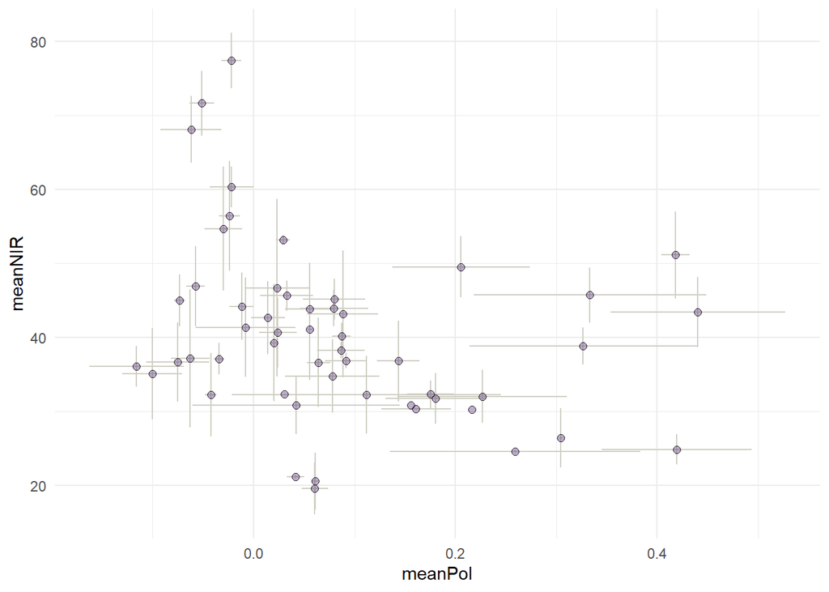

Relationship between polarization and NIR reflectivity by species

```r
ggplot(ToPlotPolbsp, aes(x = meanPol, y = meanNIR))+
  geom_errorbar(aes(ymin = meanNIR - sdNIR,
                    ymax = meanNIR + sdNIR),
                col="#cecec2") +
  geom_errorbarh(aes(xmin = meanPol - sdPol,
                     xmax = meanPol + sdPol),
                 col="#cecec2") +
  #geom_smooth (method="lm", color="#593876", fill="#D7A1F9", alpha=0.3)+
  geom_point(size=2, alpha=0.4, colour= "#593876")+
  geom_point(size=2, pch=21, colour="black", alpha=0.7)+
  theme_minimal()+
  theme(legend.position = "none")
```

**Conclusion**

**No, contrary to the hypothesis, Beetles with more polarization reflect less NIR light**  
The reason for this could be that the mechanisms used to produce high NIR reflection are different than the chiral array, and that the two mechanisms can not be present in the same beetle.

## TOT Reflectivity

**Question**

Often the total reflectivity (including both NIR and VIS) determines the potential for passive thermoregulation in ectoterms since the body is permanently exposed to both types of radiation in roughly 50-50% proportion. If polarization is correlated with total reflectance, it could have been developed as a strategy for passive thermoregulation.

**Is more polarization correlated with more reflectivity in total?**

**Tests**

There is no correlation between polarization and total reflectivity

Individual level:

```r
cor.test(RPData$R_ALL,RPData$ElytrPol)
```

```
##
##  Pearson's product-moment correlation
##
## data:  RPData$R_ALL and RPData$ElytrPol
## t = -0.50713, df = 172, p-value = 0.6127
## alternative hypothesis: true correlation is not equal to 0
## 95 percent confidence interval:
##  -0.1863381  0.1107671
## sample estimates:
##         cor
## -0.03863945
```

Species level:

```r
cor.test(RPDataAgg$R_ALL_1,RPDataAgg$ElytrPol_1)
```

```
##
##  Pearson's product-moment correlation
##
## data:  RPDataAgg$R_ALL_1 and RPDataAgg$ElytrPol_1
## t = -0.74234, df = 45, p-value = 0.4617
## alternative hypothesis: true correlation is not equal to 0
## 95 percent confidence interval:
##  -0.3849963  0.1829558
## sample estimates:
##        cor
## -0.1099898
```

```r
modPol4 <- lm(RPDataAgg$R_ALL_1~RPDataAgg$ElytrPol_1)
summary(modPol4)
```

```
##
## Call:
## lm(formula = RPDataAgg$R_ALL_1 ~ RPDataAgg$ElytrPol_1)
##
## Residuals:
##     Min      1Q  Median      3Q     Max
## -16.617  -5.935  -1.022   3.406  18.736
##
## Coefficients:
##                      Estimate Std. Error t value            Pr(>|t|)
## (Intercept)            28.851      1.467  19.669 <0.0000000000000002 ***
## RPDataAgg$ElytrPol_1   -6.620      8.918  -0.742               0.462
## ---
## Signif. codes:  0 '***' 0.001 '**' 0.01 '*' 0.05 '.' 0.1 ' ' 1
##
## Residual standard error: 8.518 on 45 degrees of freedom
## Multiple R-squared:  0.0121, Adjusted R-squared:  -0.009856
## F-statistic: 0.5511 on 1 and 45 DF,  p-value: 0.4617
```

**Plots**

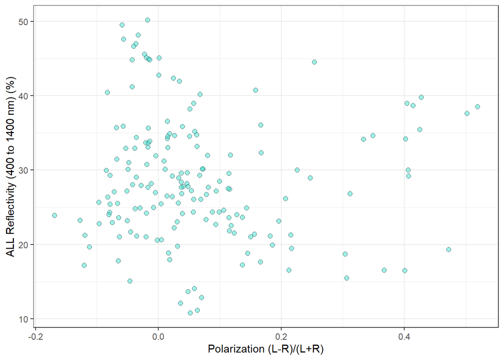

Relationship between polarization and ALL reflectivity by individual

```r
ggplot(RPData, aes(ElytrPol,R_ALL)) +
     geom_point(pch=21, bg="turquoise", col="black", alpha=0.5, size=2)+
     ylab("ALL Reflectivity (400 to 1400 nm) (%)")+
     xlab("Polarization (L-R)/(L+R)")+
     theme_bw()
```

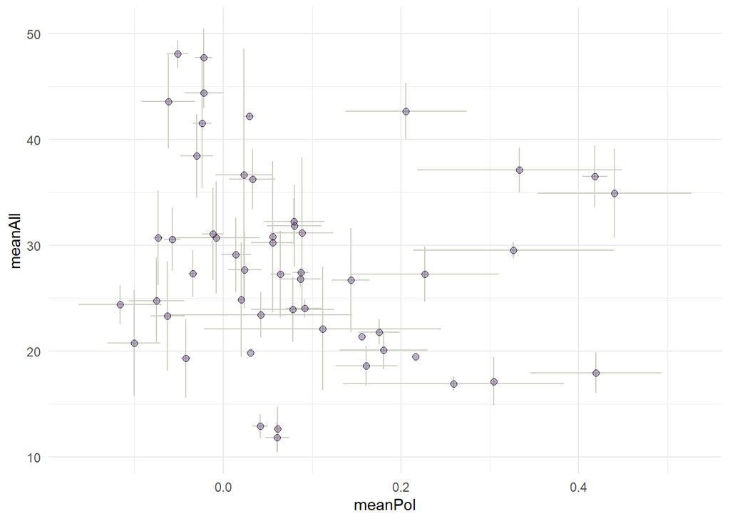

Relationship between polarization and ALL reflectivity by species

```r
ggplot(ToPlotPolbsp, aes(x = meanPol, y = meanAll))+
    geom_errorbar(aes(ymin = meanAll - sdAll,
                    ymax = meanAll + sdAll),
                col="#cecec2") +
  geom_errorbarh(aes(xmin = meanPol - sdPol,
                     xmax = meanPol + sdPol),
                 col="#cecec2") +
  geom_point(size=2, alpha=0.4, colour= "#593876")+
  geom_point(size=2, pch=21, colour="black", alpha=0.7)+
  theme_minimal()+
  theme(legend.position = "none")
```

**Conclusion**

**No, there is no correlation between polarization and total reflectiviy**  
This could be the result of the fact that visible and NIR reflectivity have opposite correlations to polarization.

## Mechanism

**Question**

In our previous studies we discovered that some species have an unusual bilayered composite material in their elytra. This material consist in a white underlay that reflects visible and NIR light with a thin cuticle on top that acts like a pigment-based filter only in the visible. As a result they produce a unique pattern of broadband NIR reflectance. This mechanism does not coexist with chiral nanostructures in the cuticle.

**Is it possible that the correlations with VIS and NIR are mainly driven by the species with white underlay?**

**Tests**

If so, removing the species with white underlay should disrupt the correlations we found in previous steps.

We removed 17 individuals belonging to the species *A. prasinus*, *Xylonichus sp.* and all three in the genus Paraschizognathus because in our previous studies we have confirmed they have a white underlay that reflects high NIR.

```r
# remove the species that contain a white underlay
nounderlay <-
  RPData %>%
  filter (phylogeny_name != "Paraschizognathus_ocularis" &
          phylogeny_name != "Paraschizognathus_prasinus"  &
          phylogeny_name != "Paraschizognathus_olivaceous"  &
          phylogeny_name != "Anoplognathus_prasinus" &
          phylogeny_name != "Xylonichus_sp")
```

Removing these species does not alter the correlation between polarization and visible reflectivity.

```r
cor.test(nounderlay$R_VIS,nounderlay$ElytrPol) #Vis
```

```
##
##  Pearson's product-moment correlation
##
## data:  nounderlay$R_VIS and nounderlay$ElytrPol
## t = 2.9222, df = 155, p-value = 0.003996
## alternative hypothesis: true correlation is not equal to 0
## 95 percent confidence interval:
##  0.07453685 0.37183613
## sample estimates:
##       cor
## 0.2285071
```

```r
modPol5 <- lm(nounderlay$R_VIS~nounderlay$ElytrPol) #by individual
summary(modPol5)
```

```
##
## Call:
## lm(formula = nounderlay$R_VIS ~ nounderlay$ElytrPol)
##
## Residuals:
##     Min      1Q  Median      3Q     Max
## -13.304  -4.665  -1.125   4.346  19.558
##
## Coefficients:
##                     Estimate Std. Error t value            Pr(>|t|)
## (Intercept)          13.9066     0.6458  21.535 <0.0000000000000002 ***
## nounderlay$ElytrPol  11.9198     4.0791   2.922               0.004 **
## ---
## Signif. codes:  0 '***' 0.001 '**' 0.01 '*' 0.05 '.' 0.1 ' ' 1
##
## Residual standard error: 7.116 on 155 degrees of freedom
## Multiple R-squared:  0.05222,    Adjusted R-squared:  0.0461
## F-statistic: 8.539 on 1 and 155 DF,  p-value: 0.003996
```

In fact, the estimate for the effect of polarization on reflectivity in our previous analysis was 11.7168456 and it is 11.9198239 after removing the species with the white underlay.

In contrast, removing these species disrupts the negative correlation between polarization and NIR.

```r
cor.test(nounderlay$R_NIR,nounderlay$ElytrPol) # nir
```

```
##
##  Pearson's product-moment correlation
##
## data:  nounderlay$R_NIR and nounderlay$ElytrPol
## t = -1.1831, df = 155, p-value = 0.2386
## alternative hypothesis: true correlation is not equal to 0
## 95 percent confidence interval:
##  -0.24757548  0.06296507
## sample estimates:
##         cor
## -0.09460615
```

This is evidenced by the change in the confidence interval: It is negative when considering all species -0.3191258, -0.0308992 but it overlaps 0 when removing the species with a white underlay -0.2475755, 0.0629651

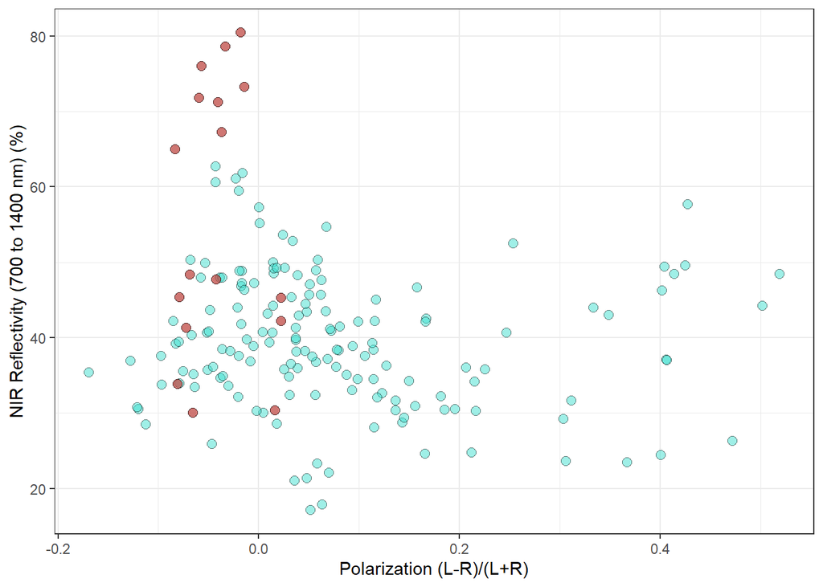

Relationship between polarization and NIR reflectivity by individual. The beetles with white underlay are shown in red.

```r
RPData2 <- RPData
# vector describing whether the beetle could potentially have a chiral cuticle
RPData2$chiral <- RPData2$ind %in% nounderlay$ind

ggplot() +
     geom_point(data = RPData2,
                mapping = aes(ElytrPol,R_NIR),
                pch=21, bg="turquoise", col="black", alpha=0.5, size=2.5)+
     geom_point(data = RPData2[RPData2$chiral=="FALSE",],
                mapping = aes(ElytrPol,R_NIR),
                pch=21, bg="red", col="black", alpha=0.5, size=2.5)+
     ylab("NIR Reflectivity (700 to 1400 nm) (%)")+
     xlab("Polarization (L-R)/(L+R)")+
     theme_bw()
```

**Conclusion**

**More polarization correlates with more VIS reflectiviy even after removing the beetles with non-chiral composite materials**

**Polarization does not reduce NIR reflectance, instead it seems like beetles with very high NIR reflectance have developed an alternate mechanism that does not involve chiral structures.**

# Results from this step

We obtained a data frame useful to compare the degree of polarization between two body parts, elytron and pronotum

```r
write.csv(BeetlePol,"../Data/FromCode/PolarzElytraPronot.csv")
```

And we also added the polarization of the elytra to a subset of the dataframe with the ecological variables and reflectance. Note that this subset may have fewer individuals that the one we will use for the phylogenetic analysis of the reflectance, but they both have the same number of species.

```r
write.csv(RPData,"../Data/FromCode/PolarzElytraRefl.csv")
```